# ATN-experiments

W. Andrew Barr

2025-04-10

## *Caveat emptor*

In the current state of code development, link weights are ignored, so if a carnivore feeds on 20 different species, then the ATN model assumes the strength of each interaction is 1/20. This is unrealistic and needs to change soon. For now the focus is on building an experimental pipeline where we can tweak the models to understand their behavior.

Also, initial biomasses between 2 and 3 are randomly assigned to all producer and consumer nodes

All other parameters are the defaults created by `ATNr::create_model_Scaled()`

## Load required dependencies and source custom functions

```r
library(ATNr)
library(dplyr)
```

```r
library(tidyr)
library(ggplot2)
library(igraph)
## load up custom functions for plotting and analysis
source("./custom_functions/makeGraphForATN.R")
source("./custom_functions/runATN.R")
source("./custom_functions/ggATNplot.R")
source("./custom_functions/plotGraphWithGuilds.R")

## import links output from Alyssa's random forest models
UBurgiLinks <- read.csv("./data/upperBurgi_species.csv")
```

## Legend for networks with guilds color coded

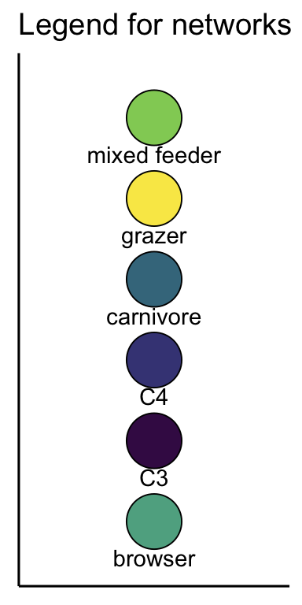

```r
  guildColors <-
  data.frame(guilds = c("browser", "C3", "C4", "carnivore", "grazer", "mixed feeder"),
             cols = c("#5FAD91","#411354", "#444585","#42778C","#F9E855", "#91CF65")
            )
ggplot(guildColors, aes(x=rep(1,6), y=1:6)) +
  geom_point(fill=guildColors$cols, size=12, pch=21) +
  geom_text(label=guildColors$guilds, y=1:6 - 0.45) +
  theme_classic(12) +
  scale_y_continuous(limits=c(0.5,6.5)) +
  scale_x_continuous(limits=c(0.98, 1.02)) +
  labs(title="Legend for networks") +
  theme(axis.title.x=element_blank(),
        axis.text.x=element_blank(),
        axis.ticks.x=element_blank(),
        axis.title.y=element_blank(),
        axis.text.y=element_blank(),
        axis.ticks.y=element_blank())
```

## Experiment 1 - number of producer nodes

### 1.1 - single C3 and single C4 producer node of equal body mass

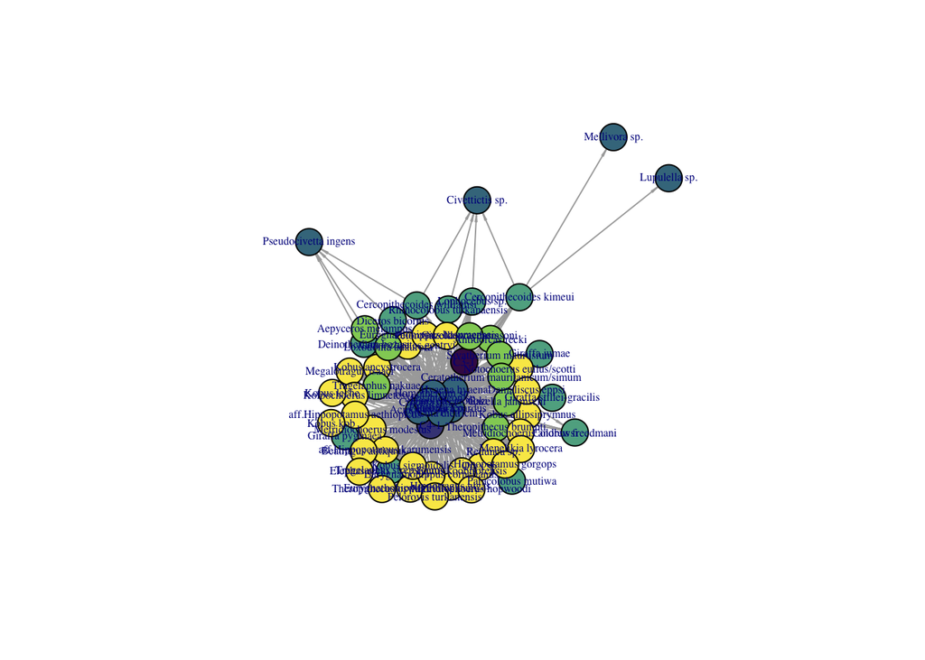

```r
g <- makeGraphForATN(linkDF = UBurgiLinks,
                     nC4 = 1,
                     nC3 = 1,
                     C4bodymass = 0.1,
                     C3bodymass = 0.1
                     )
plotGraphWithGuilds(g)
```

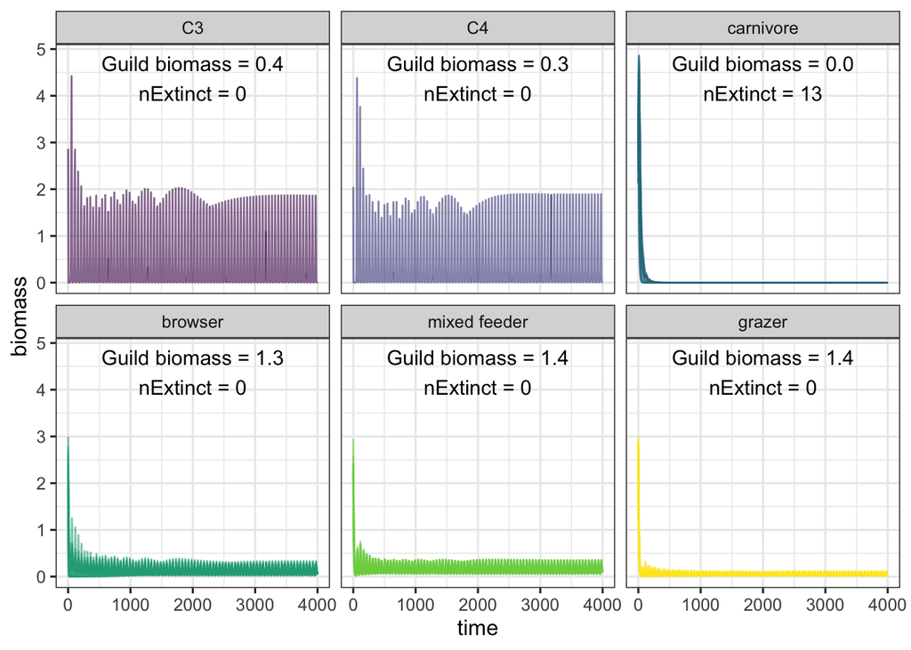

```r
solved <- runATN(graph=g)

ggATNplot(solved$solution, solved$graph)
```

### 1.2 - 10 C3 and 10 C4 producer nodes of equal body mass

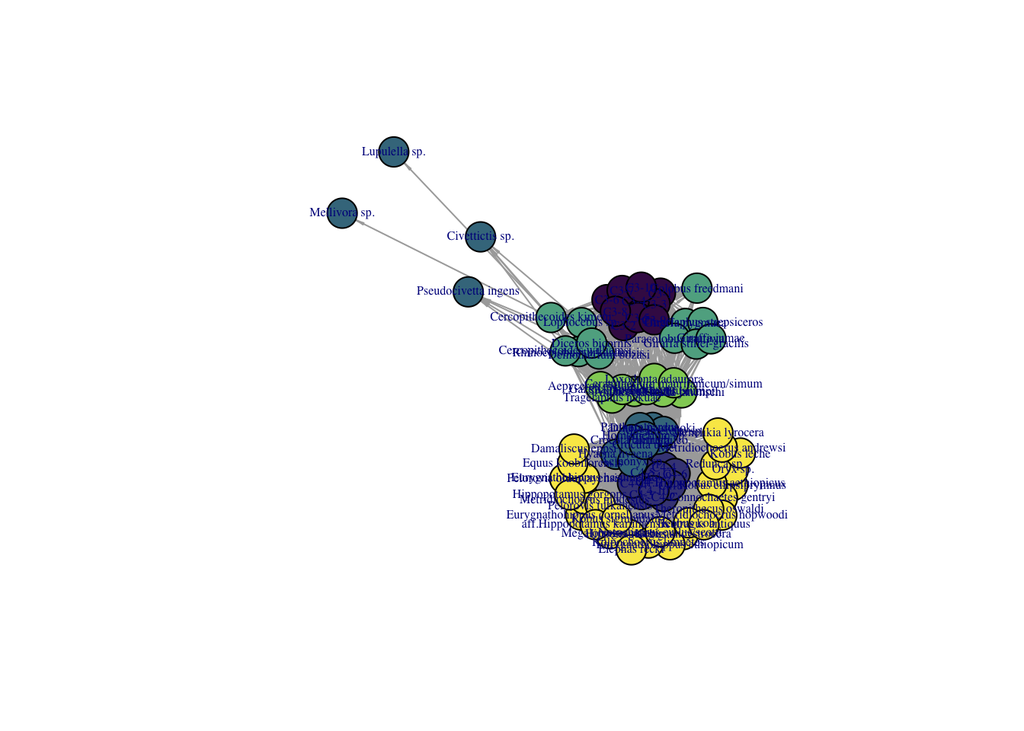

```r
g <- makeGraphForATN(linkDF = UBurgiLinks,
                     nC4 = 10,
                     nC3 = 10,
                     C4bodymass = 0.1,
                     C3bodymass = 0.1
                     )
plotGraphWithGuilds(g)
```

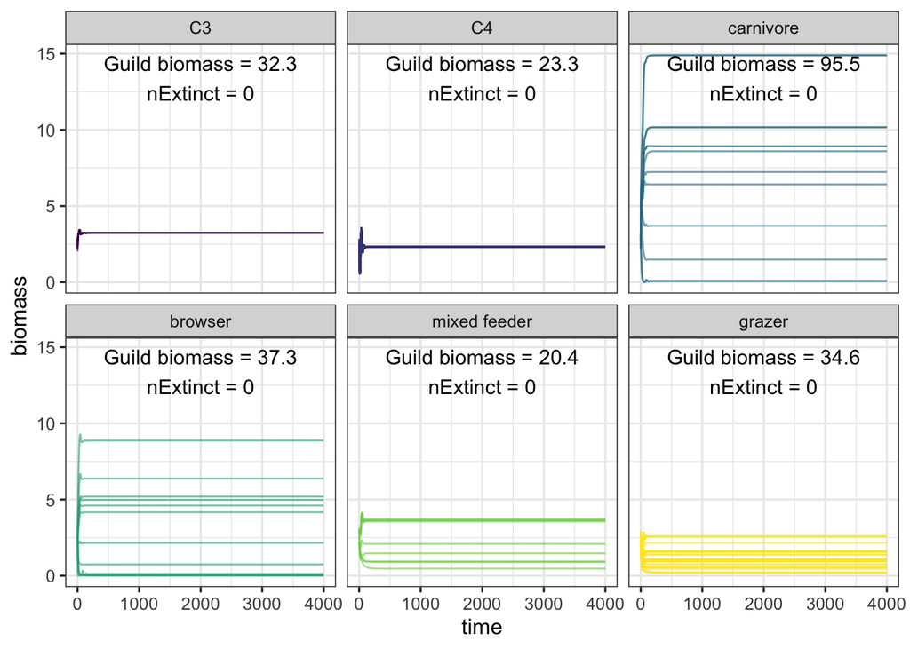

```r
solved <- runATN(graph=g)

ggATNplot(solved$solution, solved$graph)
```

### 1.3 - 100 C3 and 100 C4 producer nodes of equal body mass

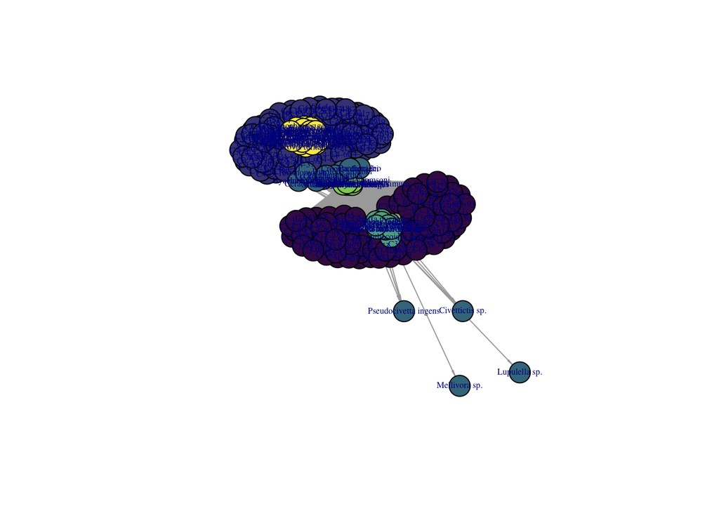

```r
g <- makeGraphForATN(linkDF = UBurgiLinks,
                     nC4 = 100,
                     nC3 = 100,
                     C4bodymass = 0.1,
                     C3bodymass = 0.1
                     )
plotGraphWithGuilds(g)
```

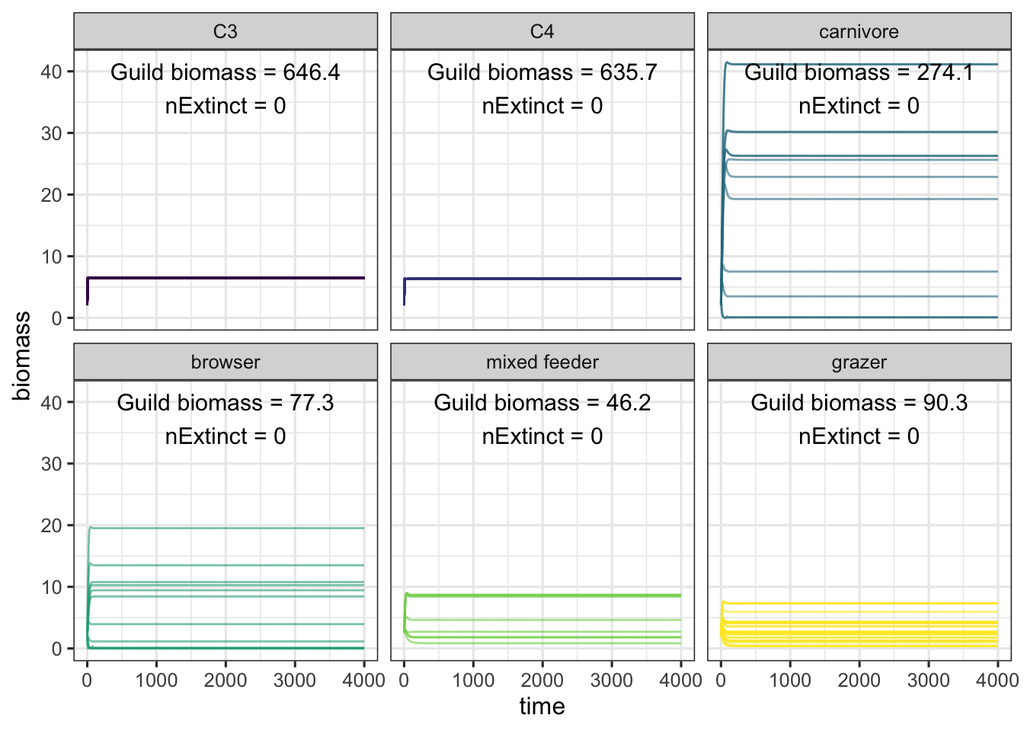

```r
solved <- runATN(graph=g)

ggATNplot(solved$solution, solved$graph)
```

### 1.4 - Reflections on Experiment 1

By adding additional producer nodes to the system we eliminate much of the biomass ‘cycling’ which occurs when there are few producer nodes.

## Experiment 2 - relative bodymass of producer nodes

### 2.1 - 100 C3 and 100 C4 producer nodes with C3 bodymass / C4 bodymass = 10

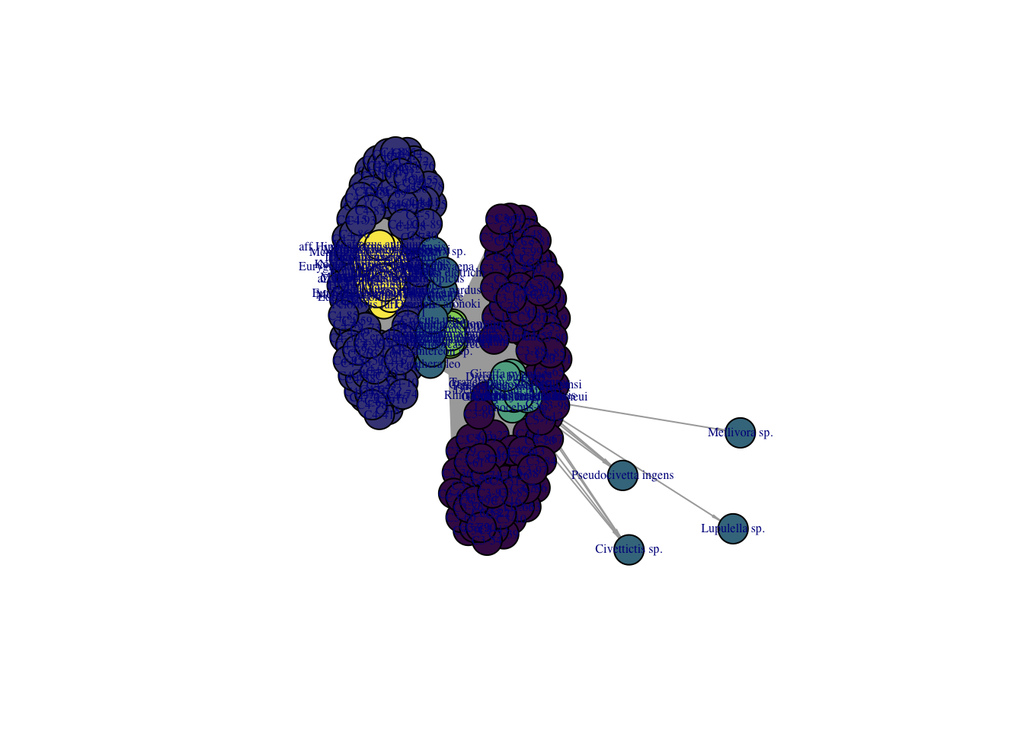

```r
g <- makeGraphForATN(linkDF = UBurgiLinks,
                     nC4 = 100,
                     nC3 = 100,
                     C4bodymass = 0.01,
                     C3bodymass = 0.1
                     )
plotGraphWithGuilds(g)
```

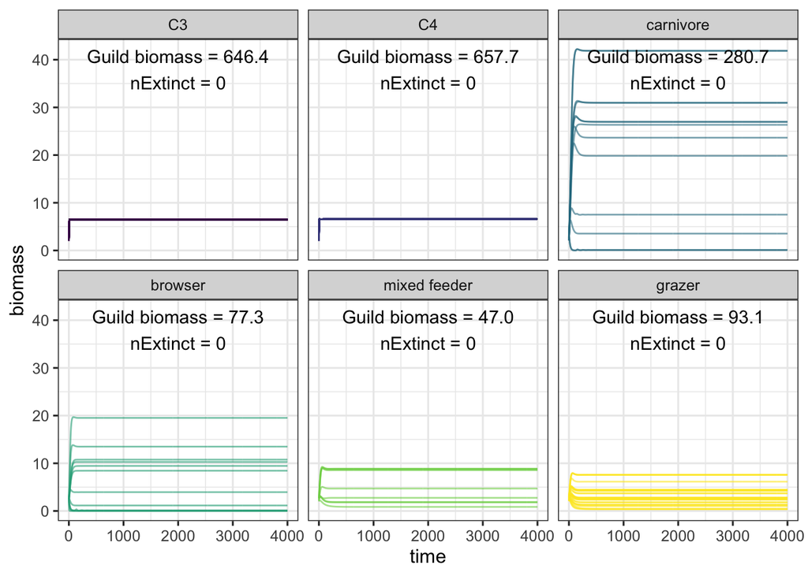

```r
solved <- runATN(graph=g)

ggATNplot(solved$solution, solved$graph)
```

### 2.2 - Reflections on Experiment 2

There is only a very small (seemingly negligible) difference between experiment 2.1 and experiment 1.3 which had identical parameters except a 10-fold difference in the C3 versus C4 node body masses, which suggests to me that the body mass of the producers isn’t a super important distinction (at least over the range of variation we have been discussing.)

## Experiment 3 - change intitial biomasses for C4 producer nodes

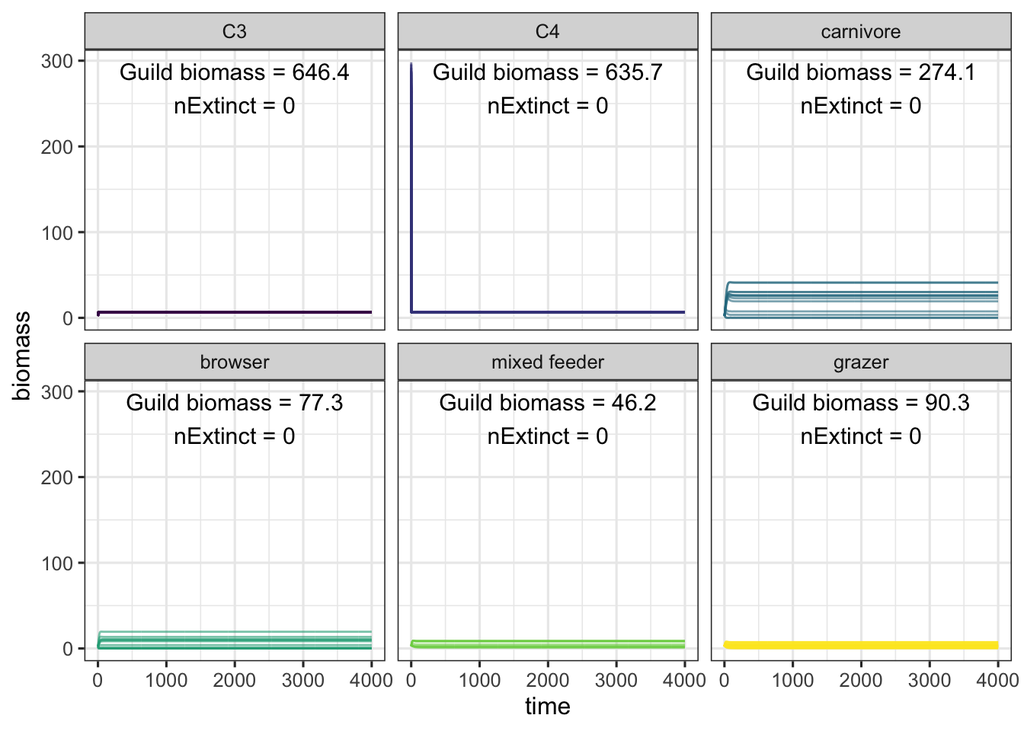

```r
g <- makeGraphForATN(linkDF = UBurgiLinks,
                     nC4 = 100,
                     nC3 = 100,
                     C4bodymass = 0.1,
                     C3bodymass = 0.1
                     )
#plotGraphWithGuilds(g)

# set up initial biomass vector sampling biomases between 2 and 3
# as done by default in the runATN function
initialBioM <- runif(length(V(g)), 2, 3)

# create a boolean vector identifying the C4
# producers based on regex match
isC4producer <- grepl("C4-", vertex_attr(g)$name)

# overwrite the initial biomasses for all C4 producers
# to be sampled between 200 and 300
# i.e. (100x the average biomass of everyone else)
initialBioM[isC4producer] <- runif(sum(isC4producer), 200, 300)

solved <- runATN(graph=g,
                 initialBiomasses = initialBioM)

ggATNplot(solved$solution, solved$graph)
```

### Reflections on experiment 3

Starting out with huge biomasses in C4 producer nodes just results in a crash and the end results are the same as in the experiment where all biomasses are the same as 1.3 - 100 C3 and 100 C4 producer nodes of equal body mass.

I presume this happens because the specified initial C4 biomasses exceed the carrying capacity and therefore immediately drop to the carrying capacity. Carrying capacity can only be tweaked globally for all producer nodes, but I modified the custom `runATN()` function to allow for competitive differences among the C4 and C3 nodes (per email recommendation from ATNr package author Benoit Gauzens)

## Experiment 4 - Tweaking alpha

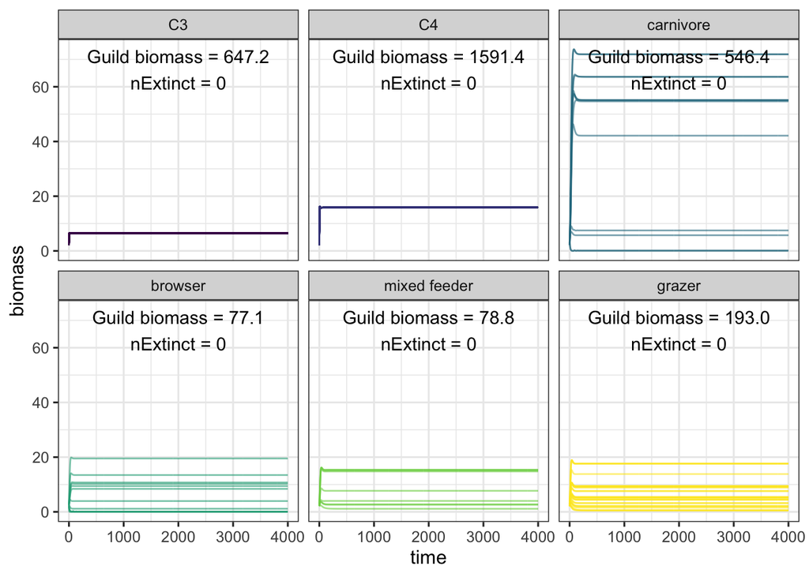

```r
g <- makeGraphForATN(linkDF = UBurgiLinks,
                     nC4 = 100,
                     nC3 = 100,
                     C4bodymass = 0.1,
                     C3bodymass = 0.1
                     )

solved <- runATN(graph=g,
                 C3IntraspecificComp = 1,
                 C4IntraspecificComp = 0.4)

ggATNplot(solved$solution, solved$graph)
```

## are body masses explaining why we have really weird results for carnivore biomasses?

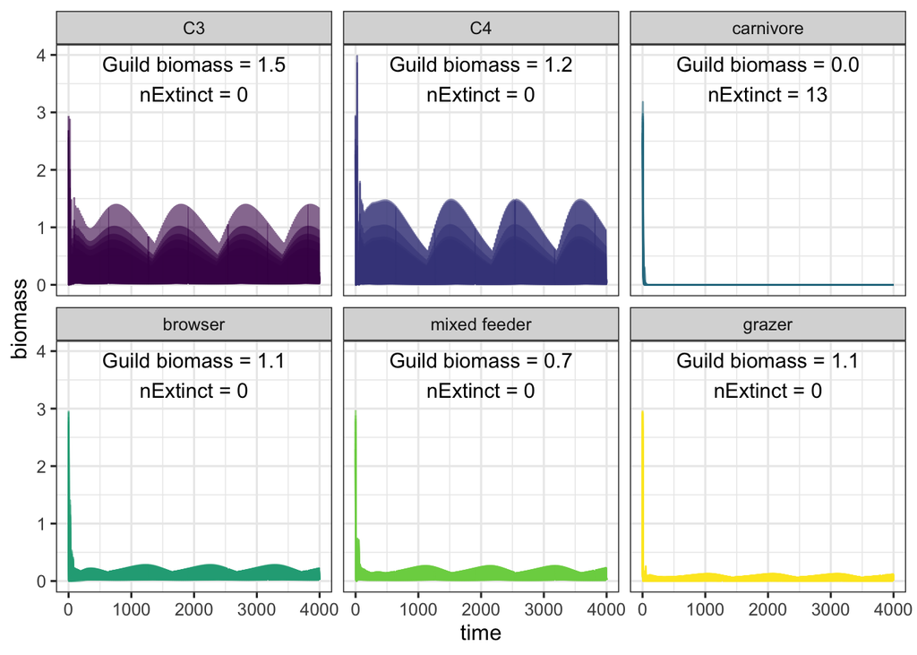

```r
g <- makeGraphForATN(linkDF = UBurgiLinks,
                     nC4 = 5,
                     nC3 = 5,
                     C4bodymass = 0.1,
                     C3bodymass = 0.1,
                     )


vertex_attr(g)$BM <- runif(length(V(g)), 1, 2) #randomly assign all body masses
#plotGraphWithGuilds(g)

solved <- runATN(graph=g, C4IntraspecificComp = 0.3, C3IntraspecificComp=1)

ggATNplot(solved$solution, solved$graph)
```